# Degree distribution and sampling effort

This R notebook represents a script for studying the foodweb degree distribution depencenty on sampling effort. As usual, let’s load the appropiate libraries:

```r
# Loading packages
library(igraph) # R famous graph library
library(data.table) # A really fast data frame
library(ggplot2) # Nice plots in R
library(gridExtra)
library(NetIndices)
library(parallel)
library(latex2exp)

# Loading Mandingley reading functions
source('../main_code/network_reading.R')
source('../main_code/network_aggregation.R')
source('../main_code/network_sampling.R')
source('../main_code/network_functions.R')
source('../main_code/misc.R')

# Loading Mandingley reading functions
source('../main_code/network_reading.R')
source('../main_code/network_aggregation.R')
source('../main_code/network_sampling.R')
source('../main_code/network_functions.R')
source('../main_code/misc.R')
```

The followin represents the main parameters of the simulation

```r
# Link attribute to be used as the weight in the network to perform the poisson sampling
simulation_attr_weight = "biomass.flow"

# Parameters for the degree distributions
simulation_S_degree             <- 200  # Number of aggregated cohorts
simulation_time_snapshot_degree <- 1223 # Time snapshot for degree distribution
simulation_tau_vals_degree      <- sapply(seq(1,9), function(x) 0.0000000001*10^x) # poisson parameter

# Parameters for the matrix visualizations
simulation_S_matrix             <- 60   # Number of aggregated cohorts
simulation_time_snapshot_matrix <- 1200 # Time snapshot
simulation_tau_vals_matrix      <- sapply(seq(1,6), function(x) 0.000000000001*100^x) # poisson parameter
```

### Loading Madingley data

Let’s continue by loading the full Madingley network at different time steps (an snapshot of the simulation), from 1200 to 1223 (around ~1000 time steps are required for the simulation to become stable):

```r
node_file <- '../../data/madingley_data/original_nodes.txt'
edge_file <- '../../data/madingley_data/original_edges.txt'

# For this analysis, let's just focus in two snapshots
snapshot_times <- c(simulation_time_snapshot_degree,simulation_time_snapshot_matrix)

# Getting two madingley objects, one for each snapshot
madingley_full_objects <- lapply(snapshot_times,  read.madingley.data, file_nodes=node_file, file_edges=edge_file, include_source_node = FALSE)
```

### Expectation of the degree distribution

For this part we will generate CDF plots of the degree distribution after cohort aggregation and link sampling is performed. The more important aspect of this analysis is the impact of the sampling effort ($\tau$) on the degree distributon. Furthermore, a comparison between the two cohort aggregation methods will be also shown.

#### Cohort aggregation

As usual, we should start by extracting the aggregated versions. For this part we will created an aggregation for each method to create an aggregated food web of $S = 200$

```r
S <- simulation_S_degree

# First snapshot corresponds to the one that will be used for degree distribution analysis
madingley_object <- madingley_full_objects[[1]]

kmeans_agg_graph_degree  <- cohort.aggregation(madingley_object, S, node.kmeans.aggregation)@G
jaccard_agg_graph_degree <- cohort.aggregation(madingley_object, S, node.jaccard.aggregation)@G
```

#### Link sampling

For this part, we will extract degree distribution expectation of a graph based on the sampling effort $\tau$ (see main document for details). The next function will help us to extract such distribution:

```r
get_expected_degree_distribution <- function(tau, G, link_attr){
  probability_matrix <- sampling.poisson.effort.prob_matrix(tau, G, link_attr)
  expected_degrees   <- round(apply(probability_matrix, 1, sum) + apply(probability_matrix, 2, sum))
  dt <- data.table(degree = expected_degrees)
  dt <- dt[,.N,by=degree]
  dt <- dt[order(-degree),]
  dt$tau <- tau
  return(data.table(degree=dt$degree, cdf=cumsum(dt$N)/sum(dt$N), tau=factor(tau)))
}
```

We can now generate the data for our analysis.

```r
taus <- simulation_tau_vals_degree

# extracting the probabilities
dt_kmeans  <- rbindlist(lapply(taus, get_expected_degree_distribution, kmeans_agg_graph_degree, simulation_attr_weight))
dt_jaccard <- rbindlist(lapply(taus, get_expected_degree_distribution, jaccard_agg_graph_degree, simulation_attr_weight))

# One analysis without aggregation
dt_madingley <- rbindlist(lapply(taus, get_expected_degree_distribution,  madingley_full_objects[[1]]@G, simulation_attr_weight))

dt_kmeans$agg_method  <- 'Mass A/J K-means'
dt_jaccard$agg_method <- 'Jaccard Trophic Similarity'

dt_aggregation = rbind(dt_kmeans, dt_jaccard)
```

The following plot show the effect of sampling on the full Madingley food web without prior aggregation:

```r
q <-qplot(data=dt_madingley, x=degree, y=cdf, log='y', size=I(2)) +
  facet_wrap(~tau, scales = "free",  labeller = label_both) +
  theme(axis.text=element_text(size=8),axis.title=element_text(size=12)) +
  theme_bw()

pdf("supplementary_figure04_full_degree_dist.pdf", width = 8, height = 8) # Open a new pdf file
q
dev.off()
```

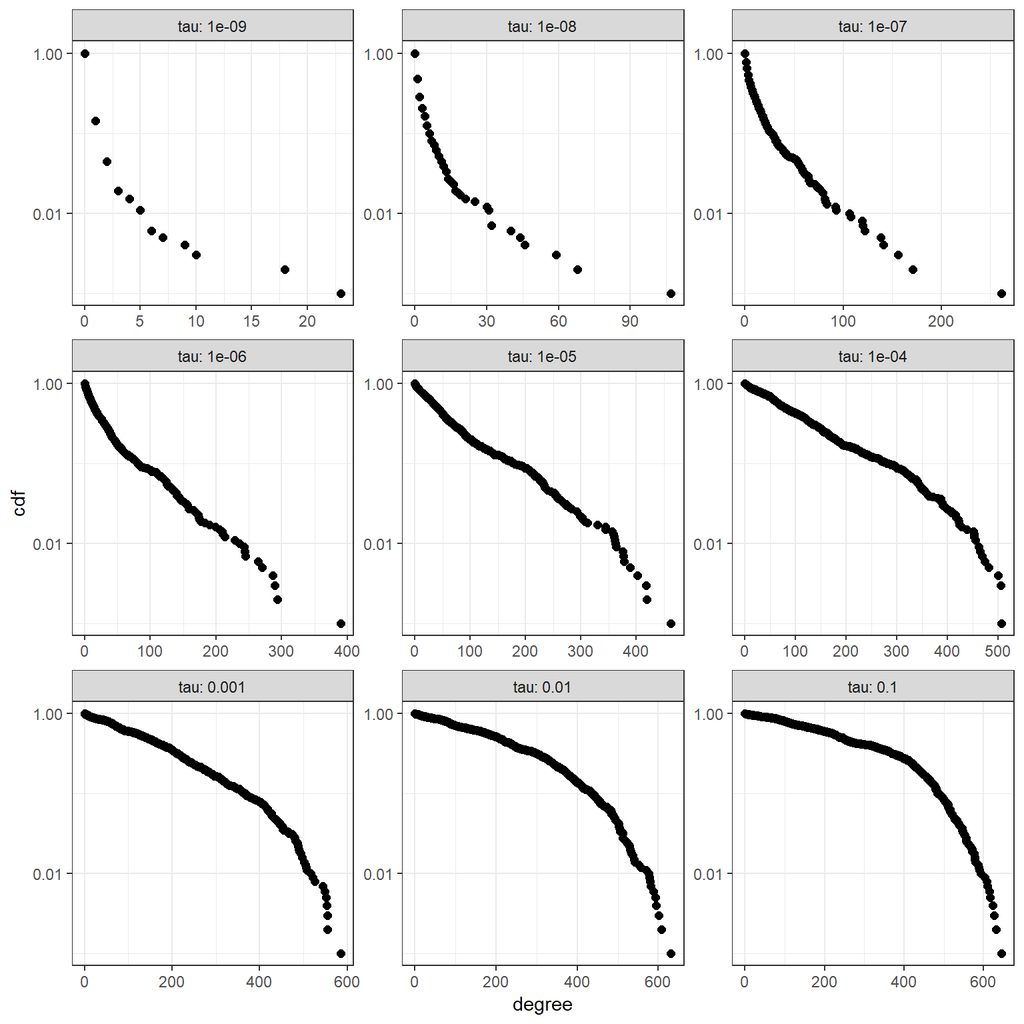

```r
q
```

```r
q <- qplot(data=dt_aggregation, x=degree, y=cdf, log='y', size=I(2),
          shape=agg_method, group = agg_method, color = agg_method) +
     facet_wrap(~tau, scales = "free",  labeller = label_both) +
     theme_bw() +
     theme(legend.title=element_blank()) +
     theme(axis.text=element_text(size=8),axis.title=element_text(size=12)) +
     theme(legend.position="top")

pdf("figure03_agg_degree_dist.pdf", width = 8, height = 8) # Open a new pdf file
q
dev.off()
```

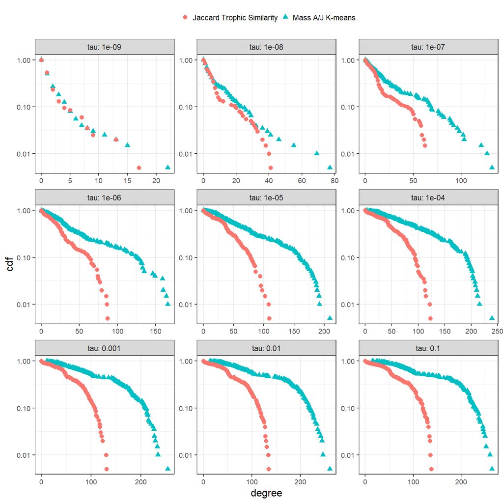

```r
q
```

### Food web sampling matrices

In this part we will create visualizations of the adjacency matrices for the Madingley aggregated sampling food webs.

#### Cohort aggregation

As usual, we should start by extracting the aggregated versions. For this part we will created an aggregation for each method to create an aggregated food web of $S = 60$

```r
S <- simulation_S_matrix
#S <- 80

# First snapshot corresponds to the one that will be used for adjacency matrix visualization
madingley_object_matrix <- madingley_full_objects[[2]]

aggregated_kmeans       <- cohort.aggregation(madingley_object_matrix, S, node.kmeans.aggregation)
aggregated_jaccard      <- cohort.aggregation(madingley_object_matrix, S, node.jaccard.aggregation)

aggregated_kmeans_G     <- aggregated_kmeans@G
aggregated_jaccard_G    <- aggregated_jaccard@G
```

We can now create a helper function to extract an adjacency probability matrix based in $\tau$ and othe properties:

```r
get_adjacency_probabilities <- function(tau, G, link_attr, sort_idx){

  matrix <- as.matrix(sampling.poisson.effort.prob_matrix(tau,G,link_attr))
  nrows  <- nrow(matrix)

  # reversing in rows, as plotting in y in the reverse of the matrix row index
  matrix <- matrix[rev(sort_idx), sort_idx]

  # melt fuction use row/column keys for creating the data frame
  rownames(matrix) <- 1:nrows
  colnames(matrix) <- 1:nrows

  # adjacency matrix a table (input for heatmap)
  df <- melt(matrix)
  colnames(df) <- c("prey", "predator", "sampling probability")
  df$tau <- tau

  return(df)
}
```

Now, we can extract the data that we need in order to create the visualization of the adjacency matrices:

```r
taus      <- simulation_tau_vals_matrix
link_attr <- simulation_attr_weight

# sort indexing for the adjacency matrix
idx_kmeans    <- sort(vertex_attr(aggregated_kmeans_G, 'M'), index.return=TRUE)$ix
idx_jaccard   <- sort(vertex_attr(aggregated_jaccard_G, 'M'), index.return=TRUE)$ix
idx_madingley <- sort(vertex_attr(madingley_object_matrix@G, 'M'), index.return=TRUE)$ix

# extracting the probabilities
dt_kmeans_matrix  <- rbindlist(lapply(taus, get_adjacency_probabilities, aggregated_kmeans_G, link_attr, idx_kmeans))
dt_jaccard_matrix <- rbindlist(lapply(taus, get_adjacency_probabilities, aggregated_jaccard_G, link_attr, idx_jaccard))

# One analysis without aggregation
dt_madingley_matrix <- rbindlist(lapply(taus, get_adjacency_probabilities, madingley_object_matrix@G, link_attr, idx_madingley))
```

The next figure represent the sampling probability for the adjacency matrix of the Madingley food web without any cohort aggregation:

```r
theme_matrix <-
  theme(aspect.ratio=1) +
  theme(panel.background = element_blank()) +
  theme(axis.text.x = element_blank(),axis.text.y = element_blank(),axis.ticks = element_blank()) +
  #theme(legend.title=element_blank()) +
     theme(axis.text=element_text(size=8),axis.title=element_text(size=12)) +
     theme(legend.position="top")

g<-ggplot(dt_madingley_matrix, aes(predator,prey, fill=`sampling probability`)) +
  scale_fill_gradient(low = "white", high = "steelblue") +
  geom_raster() +
  facet_wrap(~tau, scales = "free",  labeller = label_both) +
  theme_matrix

pdf("supplementary_figure02_full_matrices.pdf", width = 8, height = 6) # Open a new pdf file
g
dev.off()
```

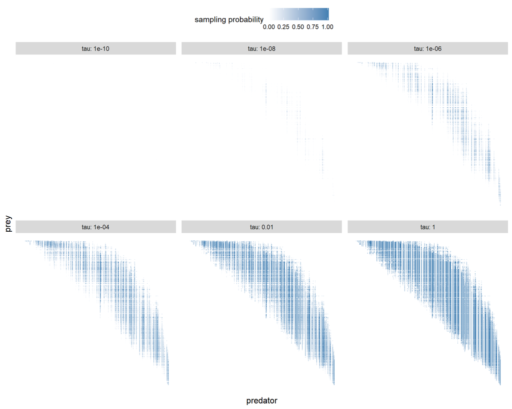

```r
print(g)
```

The next figure represent the sampling probability for the adjacency matrix after performing k-means cohort aggregation with $S=60$:

```r
g<-ggplot(dt_kmeans_matrix, aes(predator,prey, fill=`sampling probability`)) +
  scale_fill_gradient(low = "white", high = "steelblue") +
  geom_raster() +
  facet_wrap(~tau, scales = "free",  labeller = label_both) +
  theme_matrix

pdf("figure02_kmeans_matrices.pdf", width = 8, height = 6) # Open a new pdf file
g
dev.off()
```

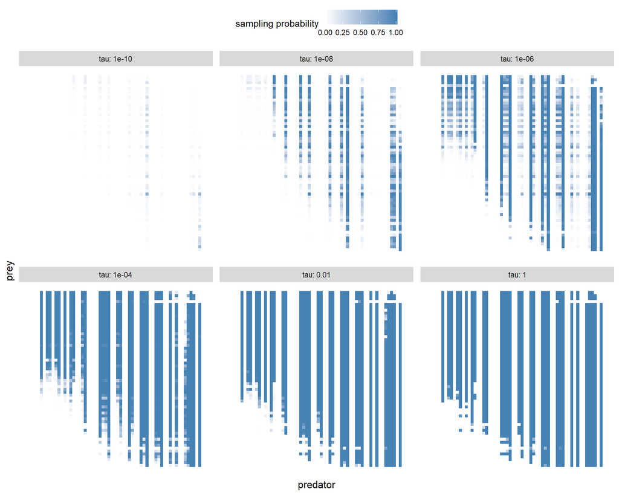

```r
print(g)
```

And finally the next figure represent the sampling probability for the adjacency matrix after performing Jaccart trophic similarity cohort aggregation with $S=60$:

```r
g<-ggplot(dt_jaccard_matrix, aes(predator,prey, fill=`sampling probability`)) +
  scale_fill_gradient(low = "white", high = "steelblue") +
  geom_raster() +
  facet_wrap(~tau, scales = "free",  labeller = label_both) +
  theme_matrix

pdf("supplementary_figure03_jaccard_matrices.pdf", width = 8, height = 6) # Open a new pdf file
g
dev.off()
```

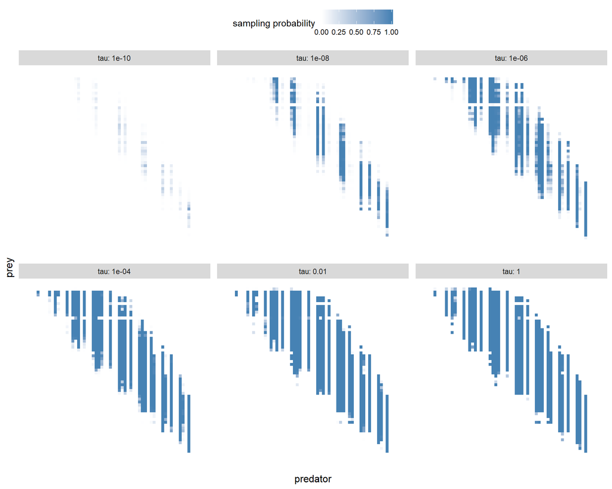

```r
print(g)
```